# SWF molder V2.0 toy examples

Marcantonio Matteo

January 15, 2024

# 1 Examples with toy matrix

8x8 pixel toy matrix made of three land use classes:

- **1 = SWF**
- **2 = Agriculture**
- **3 = forest**

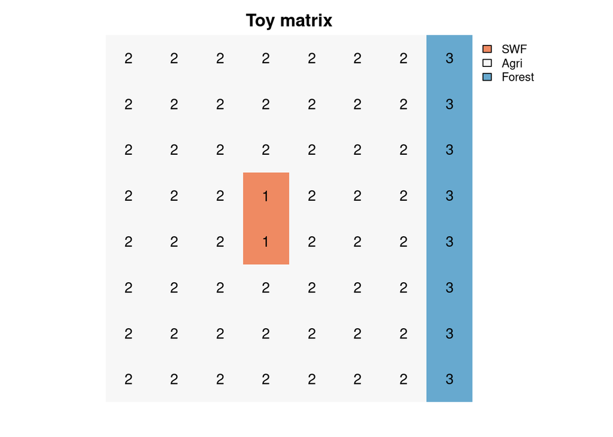

```r
#Define the toy matrix
library(terra)
toy.mt <- matrix(c(
    2,2,2,2,2,2,2,2,
    2,2,2,2,2,2,2,2,
    2,2,2,2,2,2,2,2,
    2,2,2,1,1,2,2,2,
    2,2,2,2,2,2,2,2,
    2,2,2,2,2,2,2,2,
    2,2,2,2,2,2,2,2,
    3,3,3,3,3,3,3,3), ncol=8, byrow=TRUE)

storage.mode(toy.mt) <- "integer"
color_map <- c('#ef8a62', '#f7f7f7', '#67a9cf')
plot(rast(t(toy.mt)), col = color_map, axes = FALSE, box = FALSE, main="Toy matrix", plg=list(legend=c("SWF","Agri","Forest")))
text(rast(t(toy.mt)), digits=1)
```

## 1.1 Simple ortogonal expansion

- SWF pixel with 1 Agri Neighbour
- 1 SWF px allocated per iteration
- Allocation of SWF pixels favours ortogonal Agri neighbours

```r
iters = 10
test.1 <- swf.molder(
Hmatrix = toy.mt,
swfCover=0.90,
swfCat=1,
agriCat=2,
Q=1, # number of neighbour allocated per iterations
fDiagonal=FALSE,
iterations = iters,
kernelCl=ncol(toy.mt), kernelRw=nrow(toy.mt),
NNeighbors=1, # number of px that a SWF pixel must have to be selected
maxDistance = 1,
queensCase=TRUE,
np=1,deBug=TRUE)
```

```
## Col: 1 ; Row: 1 ; SWF pixel:  2
```

```
## Iteration:  1 ; SWF cover: 0.07
```

```
## Col: 1 ; Row: 1 ; SWF pixel:  4
```

```
## Iteration:  2 ; SWF cover: 0.12
```

```
## Col: 1 ; Row: 1 ; SWF pixel:  7
```

```
## Iteration:  3 ; SWF cover: 0.21
```

```
## Col: 1 ; Row: 1 ; SWF pixel:  12
```

```
## Iteration:  4 ; SWF cover: 0.32
```

```
## Col: 1 ; Row: 1 ; SWF pixel:  18
```

```
## Iteration:  5 ; SWF cover: 0.48
```

```
## Col: 1 ; Row: 1 ; SWF pixel:  27
```

```
## Iteration:  6 ; SWF cover: 0.7
```

```
## Col: 1 ; Row: 1 ; SWF pixel:  39
```

```
## Iteration:  7 ; SWF cover: 0.84
```

```
## Col: 1 ; Row: 1 ; SWF pixel:  47
```

```
## Iteration:  8 ; SWF cover: 0.95
```

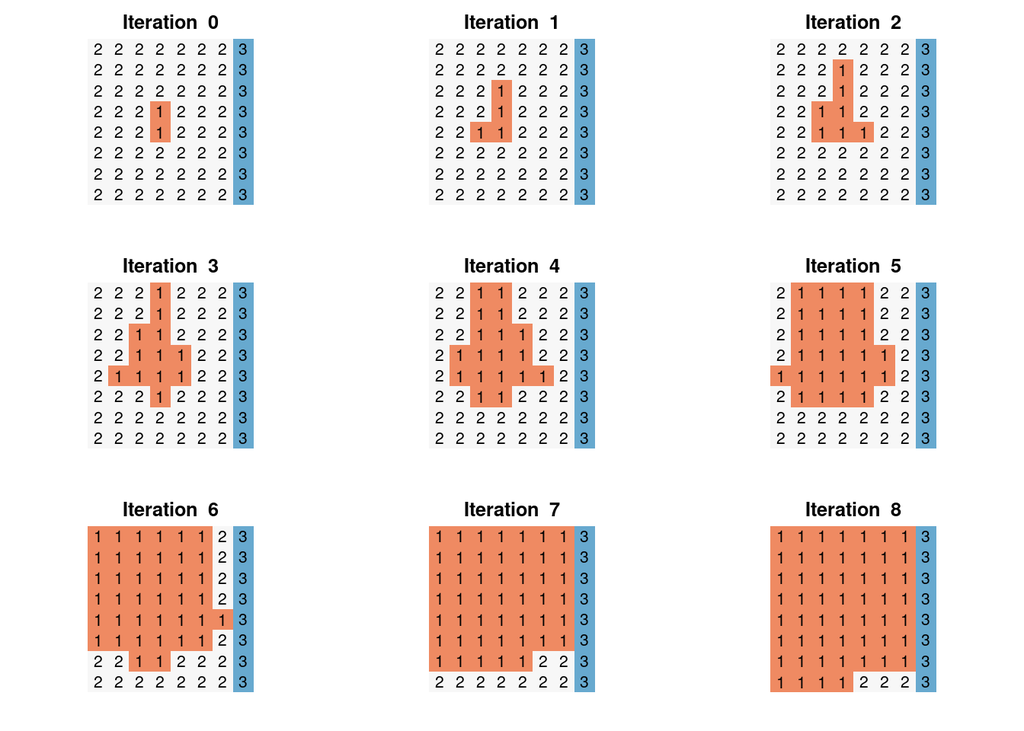

## 1.2 Simple diagonal expansion

```r
iters = 10
test.1 <- swf.molder(
Hmatrix = toy.mt,
swfCover=0.90,
swfCat=1,
agriCat=2,
fDiagonal=TRUE, # sets preferred direction of expantion
Q=1, # number of neighbour allocated per iterations
iterations = iters,
kernelCl=ncol(toy.mt), kernelRw=nrow(toy.mt),
NNeighbors=1, # number of px that a SWF pixel must have to be selected
maxDistance = 1,
queensCase=TRUE,
np=1)
```

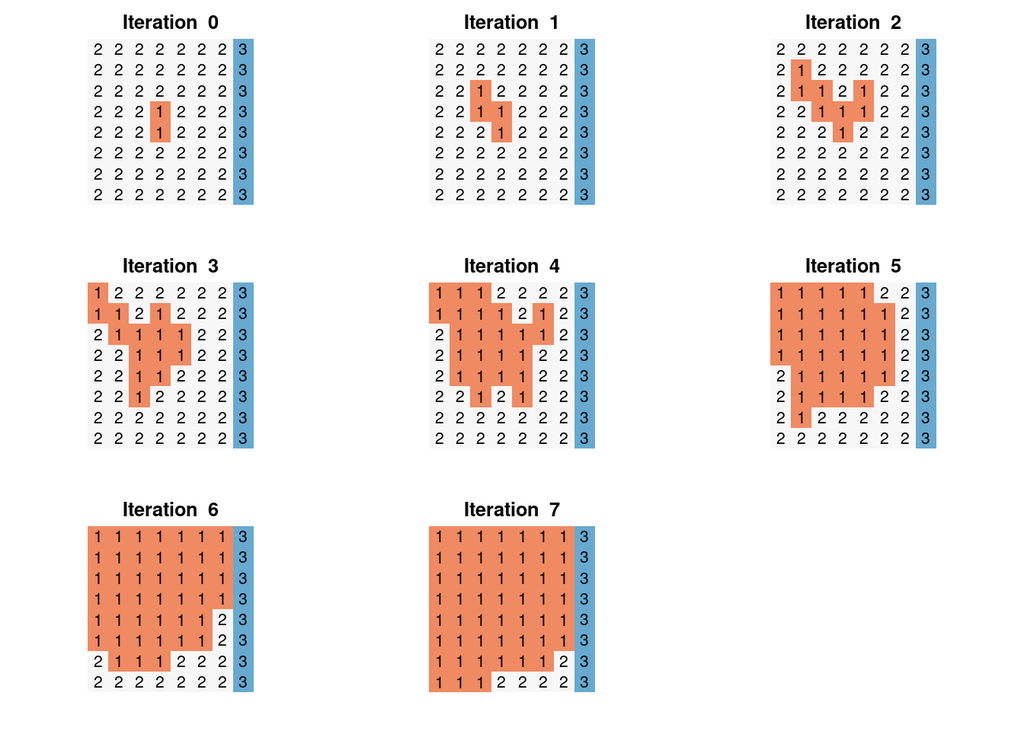

## 1.3 Simple lateral expansion

```r
iters = 3
test.1 <- swf.molder(
Hmatrix = toy.mt,
swfCover=0.90,
swfCat=1,
agriCat=2,
fDiagonal=FALSE, # sets preferred direction of expantion
Q=1, # number of neighbour allocated per iterations
iterations = iters,
kernelCl=ncol(toy.mt), kernelRw=nrow(toy.mt),
NNeighbors=7, # number of px that a SWF pixel must have to be selected
maxDistance = 1,
queensCase=FALSE,
np=1)
```

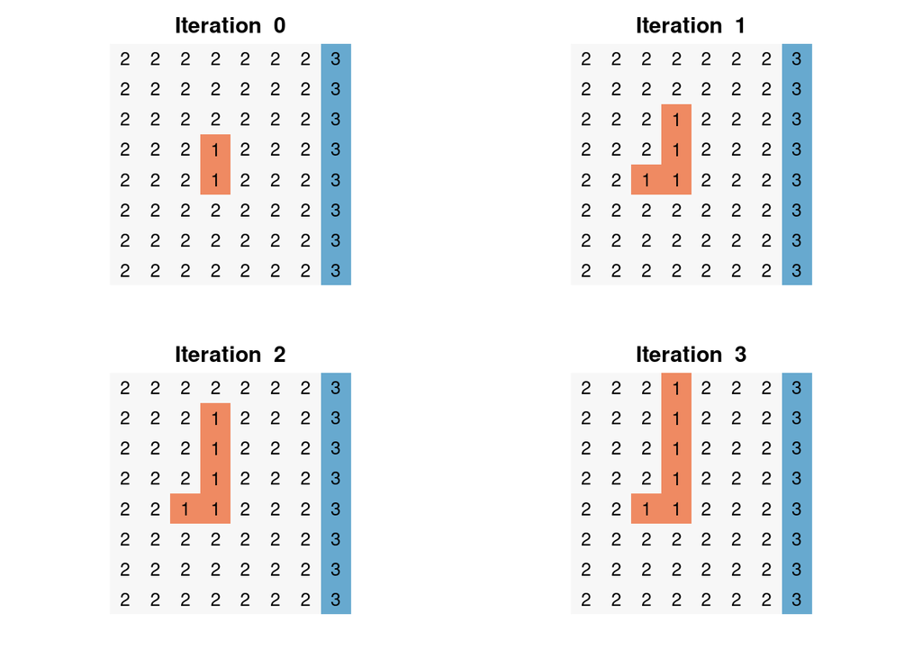

## 1.4 Expansion driven by multiple neighbours and SWF allocation, ortogonal

- SWF pixel with 5 Agri Neighbour
- 2 SWF px allocated per iteration
- Allocation of new SWF pixels favours *orthogonal* Agri neighbours

```r
iters = 10
test.1 <- swf.molder(
Hmatrix = toy.mt,
swfCover=0.90,
swfCat=1,
agriCat=2,
fDiagonal=FALSE, # sets preferred direction of expantion
Q=2, # number of neighbour allocated per iterations
iterations = iters,
kernelCl=ncol(toy.mt), kernelRw=nrow(toy.mt),
NNeighbors=5, # number of px that a SWF pixel must have to be selected
maxDistance = 1,
queensCase=TRUE,
np=1)
```

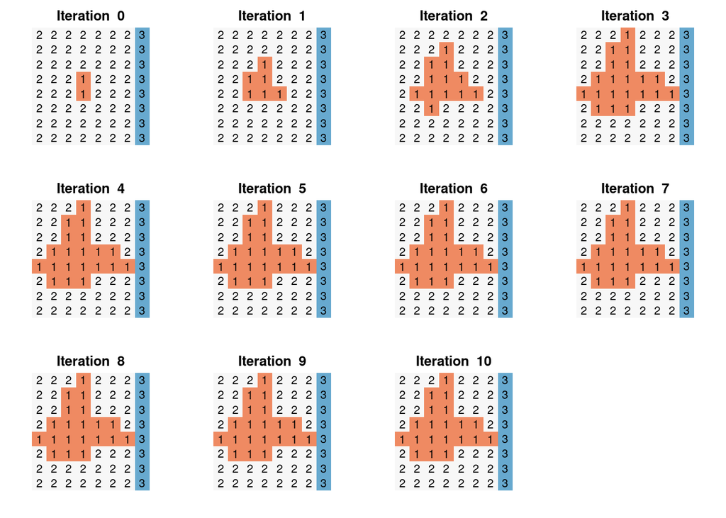

## 1.5 Expansion driven by multiple neighbours and SWF allocation, diagonal

- SWF pixel with 5 Agri Neighbour
- 2 SWF px allocated per iteration
- Allocation of new SWF pixels favours *diagonal* Agri neighbours

```r
iters = 10
test.1 <- swf.molder(
Hmatrix = toy.mt,
swfCover=0.90,
swfCat=1,
agriCat=2,
fDiagonal=TRUE, # sets preferred direction of expantion
Q=2, # number of neighbour allocated per iterations
iterations = iters,
kernelCl=ncol(toy.mt), kernelRw=nrow(toy.mt),
NNeighbors=5, # number of px that a SWF pixel must have to be selected
maxDistance = 1,
queensCase=TRUE,
np=1)
```

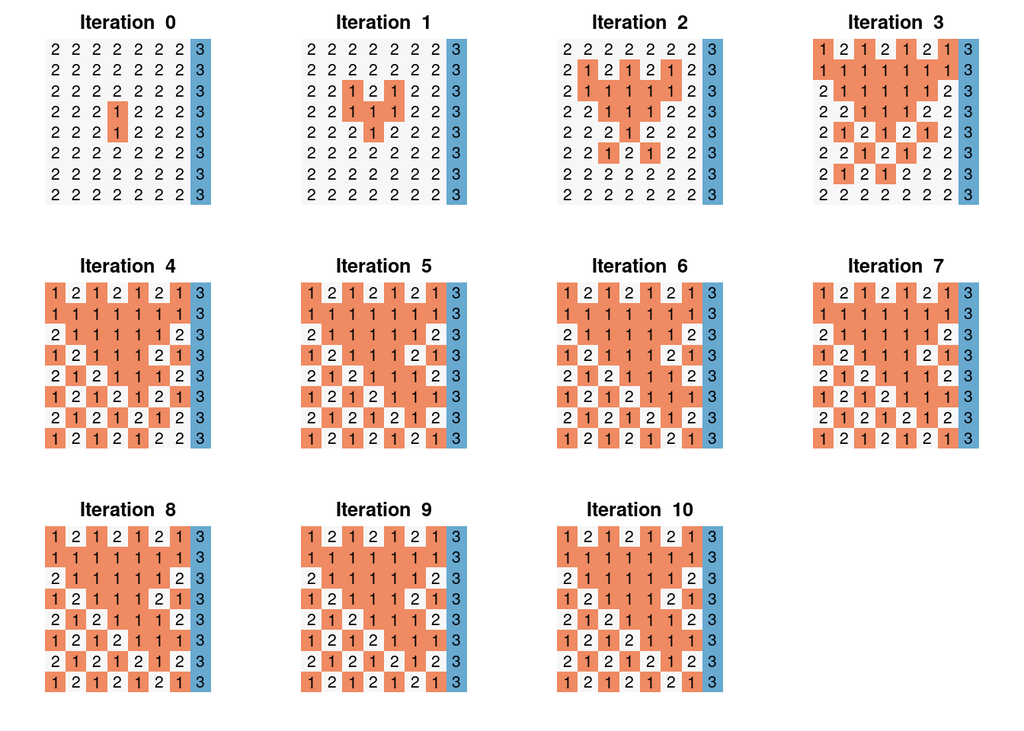

## 1.6 Expansion following a 1st order “buffer”

- SWF pixel with 1 Agri Neighbour
- 7 SWF px allocated per iteration

```r
iters = 10
test.1 <- swf.molder(
Hmatrix = toy.mt,
swfCover=0.90,
swfCat=1,
agriCat=2,
fDiagonal=FALSE, # sets preferred direction of expantion
Q=7, # number of neighbour allocated per iterations
iterations = iters,
kernelCl=ncol(toy.mt), kernelRw=nrow(toy.mt),
NNeighbors=1, #number of px that a SWF pixel must have to be selected
maxDistance = 1,
queensCase=TRUE,
np=1)
```

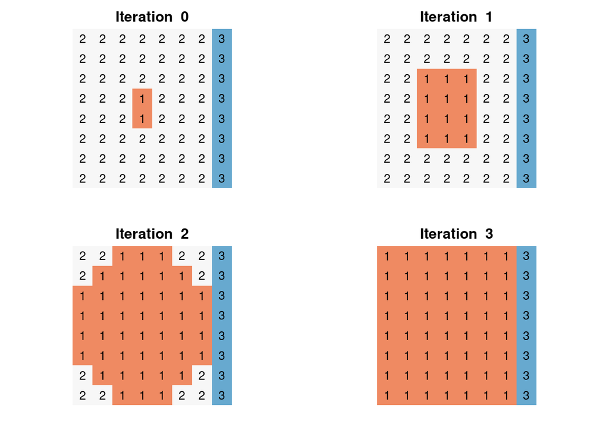

## 1.7 Expansion following a 2nd order “buffer”

This mimics a 2nd order “buffer” approach. To obtain it, the minimum number of Agri NN for each SWF pixel must be 1 and the number of new allocated SWF pixel has to be the maximum number of 2nd order Agri neighbours that the SWF pixel has in the toy example (8+16=24).

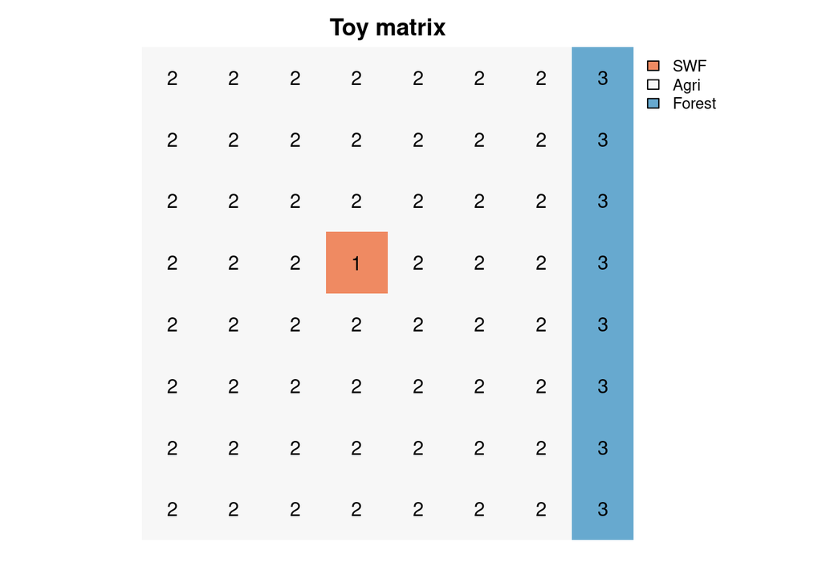

```r
# Remaking the toy matrix with only 1 SWF pixel to make it easier to interpret
toy.mt <- matrix(c(
    2,2,2,2,2,2,2,2,
    2,2,2,2,2,2,2,2,
    2,2,2,2,2,2,2,2,
    2,2,2,1,2,2,2,2,
    2,2,2,2,2,2,2,2,
    2,2,2,2,2,2,2,2,
    2,2,2,2,2,2,2,2,
    3,3,3,3,3,3,3,3), ncol=8, byrow=TRUE)
plot(rast(t(toy.mt)), col = color_map, axes = FALSE, box = FALSE, main="Toy matrix", plg=list(legend=c("SWF","Agri","Forest")))
text(rast(t(toy.mt)), digits=1)
```

- SWF pixel with 1 Agri Neighbour
- 24 SWF px allocated per iteration

```r
iters = 10
test.1 <- swf.molder(
Hmatrix = toy.mt,
swfCover=0.90,
swfCat=1,
agriCat=2,
fDiagonal=FALSE, # sets preferred direction of expantion
Q=24, # number of neighbour allocated per iterations
iterations = iters,
kernelCl=ncol(toy.mt), kernelRw=nrow(toy.mt),
NNeighbors=1, #number of px that a SWF pixel must have to be selected
maxDistance = 1,
queensCase=TRUE,
np=1)
```

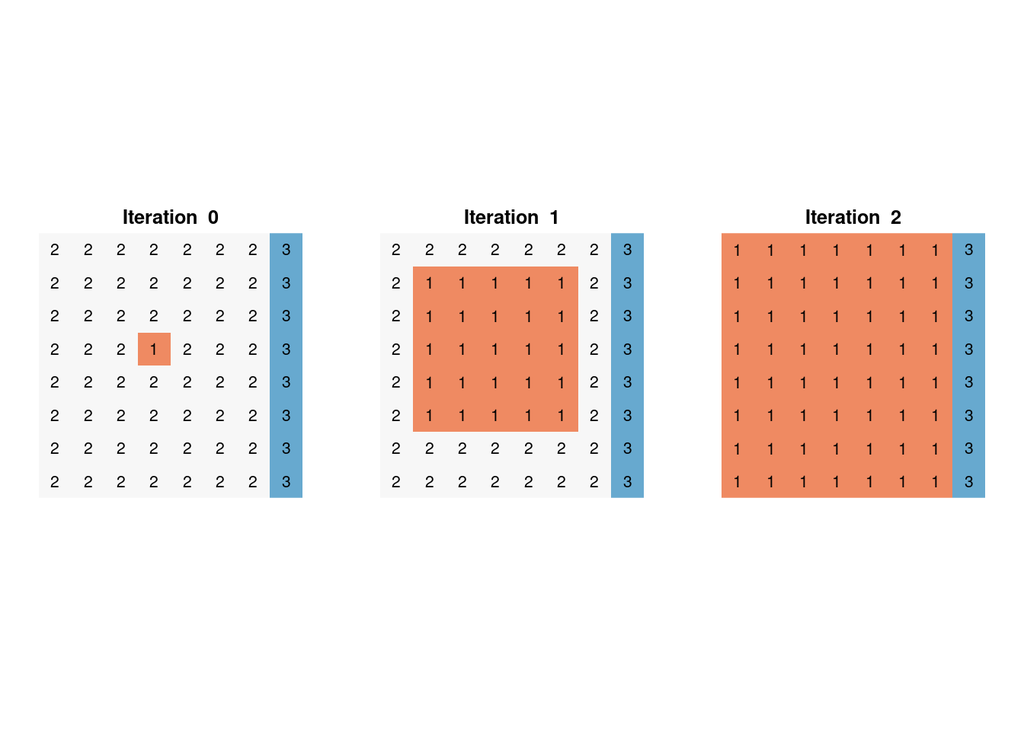